# Python Apps

Launching Python Applications from VS Code

Python

Development Tools

Author

Martin Frigaard

Published

July 13, 2024

**NoteNote**

This is the second post on working in VS Code with Python. I’ll cover developing and publishing Python applications using Bokeh, Streamlit, and Dash.

I’ve been building quite a few Python applications with VS Code lately and thought I’d write some observations on [Bokeh](https://docs.bokeh.org/en/latest/), [Streamlit](https://docs.streamlit.io/), and [Dash](https://dash.plotly.com/). I’ll cover managing dependencies, a few key differences between Python and R, and running the applications in VS Code.

## Virtual environments

Python virtual environments are designed to manage project-specific dependencies and ensure that the correct versions of packages are used in a given project. Similar to the [`renv` package](https://rstudio.github.io/renv/articles/renv.html) in R, Python comes with a a [`venv` command](https://docs.python.org/3/library/venv.html) for creating a virtual environment.[^1] It’s common practice to name the virtual environment something like `myenv` or `.venv`.

```bash
python -m venv .venv
```

`venv` works by creating a directory with a copy of the Python interpreter and the necessary executables to use it. After creating the virtual environment folder, we can activate it using the following command:

```bash
source .venv/bin/activate
# windows
# myenv\Scripts\activate
```

If you’re using VS Code, this activate the following prompt to set your workspace folder:

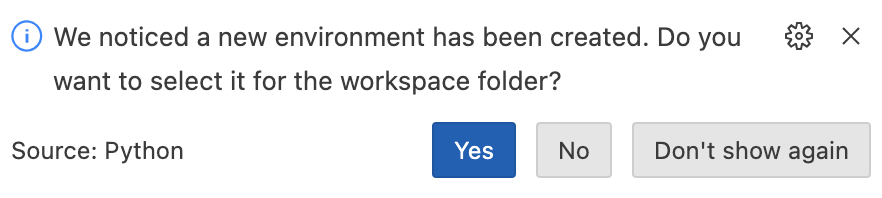

Workspace folder

Click **Yes**, then make sure all the dependencies listed in the `requirements.txt` file are installed in the virtual environment using [`pip`](https://pypi.org/project/pip/), the package installer for Python.

```bash
pip install -r requirements.txt
```

As you’re developing, new dependencies can be recorded in `requirements.txt` using `pip freeze`:

```bash
pip freeze > requirements.txt
```

The .`venv/` directory will store the Python version and packages used in the Python project:

```bash
.venv/
  └──lib/
      └── python3.9/
            └── site-packages/
```

Packages installed into `.venv/lib/python3.9/site-packages` do not affect the global Python installation or other virtual environments. This isolation helps prevent version conflicts and makes dependency management easier.

### Git history

The virtual environment will store all the dependencies for a project, so it’s a good practice to remove it from any Git repositories. You can do this with the following commands in the terminal:

```bash
echo ".venv/" >> .gitignore
git add .gitignore
git commit -m "Add .venv to .gitignore"
```

You can also remove the `.venv` directory from the latest commit:

```bash
git rm -r --cached .venv
git commit -m "Remove .venv directory"
```

**TipUsing `venv`**

`venv` allows us to manage dependencies more effectively, ensuring a clean and isolated environment for each Python app project.

```bash
# create a virtual environment
python -m venv .venv

# activate the virtual environment on macOS/Linux
source .venv/bin/activate

# install necessary packages
pip install dash streamlit bokeh

# save your current environment's packages
pip freeze > requirements.txt

# install the packages in a new environment
pip install -r requirements.txt

# deactivate the virtual environment when done
deactivate
```

[Bokeh](https://docs.bokeh.org/en/latest/), [Streamlit](https://docs.streamlit.io/), and [Dash](https://dash.plotly.com/) are three popular libraries for creating interactive Python applications, particularly for visualizations and dashboards. Below we’ll explore building an application in each framework using the [`palmerpenuins` data](https://allisonhorst.github.io/palmerpenguins/). For uniformity, each app will include a scatter plot comparing the numeric variables and a table output.

## Bokeh

[figure not shown]

[Bokeh](https://docs.bokeh.org/en/latest/) is a library in Python specifically designed for creating interactive and visually appealing interactive graphs and charts. Bokeh can also create static HTML files without a server, similar to RMarkdown’s HTML output.

### Importing Libraries

Create a `main.py` script and install the following libraries using `pip`. `pandas` is for data manipulation, `bokeh` will be used for the interactive visualizations, and the `palmerpenguins` package will load the `penguins` dataset.

```python
import pandas as pd
from bokeh.layouts import column, row
from bokeh.models import ColumnDataSource, DataTable, TableColumn, NumberFormatter, Select
from bokeh.plotting import figure, curdoc
from palmerpenguins import load_penguins
```

in R, we might use `dplyr` for data manipulation and `ggplot2` for visualizations. For interactive visualizations, we might use `plotly`.

**Tip**Python vs. R**: Key Differences When Importing Libraries**

**Library Import Syntax**

Python emphasizes explicit control over imports and namespaces:

- Python uses the `import` statement
  - `import package_name`
- Aliases are often used to shorten package names
  - `import package_name as alias`
- Python uses `from` to import specific functions or classes
  - `from package_name import specific_function`

R uses the `library()` or `require()` function to import packages. R loads the entire package into the namespace by default. If you have functions with the same name in different packages, you can specify the package explicitly with `package::function()`.

### Loading Data

The `penguins` dataset is loaded into a `pandas` DataFrame using `load_penguins()` and the missing data is removed with `df.dropna()`.

```python
df = load_penguins()
df = df.dropna()
```

A `ColumnDataSource` is created from the `DataFrame`, which is used by Bokeh for efficient data handling (this intermediate step doesn’t really have an R equivalent).

```python
source = ColumnDataSource(df)
```

A list of numeric columns is defined to use in the scatter plot drop-downs. If we were doing this in R, we could use `colnames()` or `dplyr::select()`:

```python
numeric_columns = ['bill_length_mm', 'bill_depth_mm', 'flipper_length_mm', 'body_mass_g']
```

### App Inputs

Two drop-down `Select()` widgets can be created for selecting x and y axes variables.

```python
x_select = Select(title="X Axis", value="bill_length_mm", options=numeric_columns)
y_select = Select(title="Y Axis", value="bill_depth_mm", options=numeric_columns)
```

If this was a Shiny app, we would use `selectInput()`.

### Scatter Plot

We can initialize a scatter plot with the default axis labels and data:

```python
scatter_plot = figure(title="Scatter Plot",
                      x_axis_label='Bill Length (mm)',
                      y_axis_label='Bill Depth (mm)')
scatter_plot.scatter(x='bill_length_mm', y='bill_depth_mm', source=source, size=10)
```

In `ggplot2`, this would look like:

**show/hide ggplot2 equivalent code**

```r
ggplot(df,
  aes(x = bill_length_mm, y = bill_depth_mm)) +
  geom_point()
```

### Interactivity

Below we define `update_plot()`, a function for updating the scatter plot when a new variable is selected for the x or y axis. It changes axis labels and re-renders the plot with new data.

```python
def update_plot(attr, old, new):
    x = x_select.value
    y = y_select.value
    scatter_plot.xaxis.axis_label = x.replace('_', ' ').title()
    scatter_plot.yaxis.axis_label = y.replace('_', ' ').title()
    scatter_plot.renderers = []  # clear existing renderers
    scatter_plot.scatter(x=x, y=y, source=source, size=10)

x_select.on_change("value", update_plot)
y_select.on_change("value", update_plot)
```

In `shiny`, you would use `observeEvent()` or `reactive()` to update plots dynamically.

### Table Display

The code below defines `columns` and their formatters for the data table to be displayed. `DataTable()` creates `data_table`, a DataTable widget that displays the data. This is similar to using `DT::datatable(df)` in R.

```python
columns = [
    TableColumn(field="species", title="Species"),
    TableColumn(field="island", title="Island"),
    TableColumn(field="bill_length_mm", title="Bill Length (mm)", formatter=NumberFormatter(format="0.0")),
    TableColumn(field="bill_depth_mm", title="Bill Depth (mm)", formatter=NumberFormatter(format="0.0")),
    TableColumn(field="flipper_length_mm", title="Flipper Length (mm)", formatter=NumberFormatter(format="0")),
    TableColumn(field="body_mass_g", title="Body Mass (g)", formatter=NumberFormatter(format="0")),
    TableColumn(field="sex", title="Sex"),
    TableColumn(field="year", title="Year", formatter=NumberFormatter(format="0"))
]

data_table = DataTable(source=source, columns=columns, width=800)
```

### Layout

The `layout` is defined using `column` and `row` and added to the current document for rendering. In `shiny`, you would use `fluidPage()`, `sidebarLayout()`, `mainPanel()`, etc., to arrange UI components.

```python
layout = column(row(x_select, y_select), scatter_plot, data_table)
curdoc().add_root(layout)
```

### Run the App

To run this code, save `main.py` and use the `bokeh serve` command:

```python
bokeh serve --show main.py
```

In R, you would run a `shiny` app using `shinyApp(ui, server)` and the `runApp()` function.

The full code in `main.py` is available below:

**show/hide main.py**

```python
import pandas as pd
from bokeh.layouts import column, row
from bokeh.models import ColumnDataSource, DataTable, TableColumn, NumberFormatter, Select
from bokeh.plotting import figure, curdoc
from palmerpenguins import load_penguins

# load the penguins dataset
df = load_penguins()

# drop missing data
df = df.dropna()

# create ColumnDataSource
source = ColumnDataSource(df)

# numeric columns
numeric_columns = ['bill_length_mm', 'bill_depth_mm', 'flipper_length_mm', 'body_mass_g']

# create select widgets for x and y axis
x_select = Select(title="X Axis", value="bill_length_mm", options=numeric_columns)
y_select = Select(title="Y Axis", value="bill_depth_mm", options=numeric_columns)

# scatter plot comparing selected variables
scatter_plot = figure(title="Scatter Plot",
                      x_axis_label='Bill Length (mm)',
                      y_axis_label='Bill Depth (mm)')

scatter_plot.scatter(x='bill_length_mm', y='bill_depth_mm', source=source, size=10)

def update_plot(attr, old, new):
    x = x_select.value
    y = y_select.value
    scatter_plot.xaxis.axis_label = x.replace('_', ' ').title()
    scatter_plot.yaxis.axis_label = y.replace('_', ' ').title()
    scatter_plot.renderers = []  # Clear existing renderers
    scatter_plot.scatter(x=x, y=y, source=source, size=10)

x_select.on_change("value", update_plot)
y_select.on_change("value", update_plot)

# define columns
columns = [
    TableColumn(field="species", title="Species"),
    TableColumn(field="island", title="Island"),
    TableColumn(field="bill_length_mm", title="Bill Length (mm)", formatter=NumberFormatter(format="0.0")),
    TableColumn(field="bill_depth_mm", title="Bill Depth (mm)", formatter=NumberFormatter(format="0.0")),
    TableColumn(field="flipper_length_mm", title="Flipper Length (mm)", formatter=NumberFormatter(format="0")),
    TableColumn(field="body_mass_g", title="Body Mass (g)", formatter=NumberFormatter(format="0")),
    TableColumn(field="sex", title="Sex"),
    TableColumn(field="year", title="Year", formatter=NumberFormatter(format="0"))
]

# create DataTable
data_table = DataTable(source=source, columns=columns, width=800)

# Layout
layout = column(row(x_select, y_select), scatter_plot, data_table)

# add layout to curdoc
curdoc().add_root(layout)
```

After running the `bokeh serve` command, the terminal will display the local URL we can use to view our app:

```bash
Starting Bokeh server version 3.4.2 (running on Tornado 6.4)
User authentication hooks NOT provided (default user enabled)
Bokeh app running at: http://localhost:5006/main
Starting Bokeh server with process id: 88167
WebSocket connection opened
ServerConnection created
```

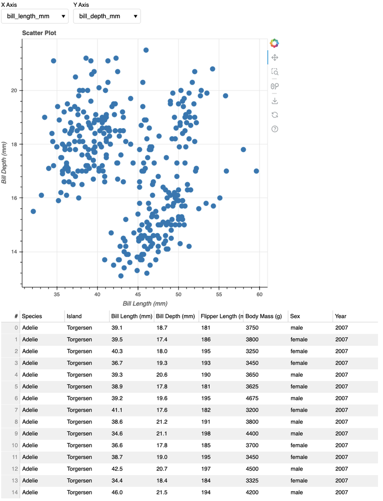

Bokeh Python App

As we can see, the layout is simple, and it gets the job done quickly with a modest amount of code. Bokeh is not really designed for full-fledged applications, but it *is* capable of creating detailed and interactive plots and tables.

## Streamlit

[figure not shown]

[Streamlit](https://docs.streamlit.io/) is another library for creating web applications for data analysis and visualization. It’s known for its simplicity and generally requires less code to build functional applications.

### Importing Libraries

After creating and activating a Python virtual environment with `venv`, ensure you have `streamlit`, `palmerpenguins`, and the other necessary libraries installed using `pip`. Create an `app.py` file and import the following libraries:

```python
import streamlit as st
import pandas as pd
import seaborn as sns
import matplotlib.pyplot as plt
from palmerpenguins import load_penguins
```

### Loading Data

Load the `penguins` data as a `pandas` `DataFrame` using the `load_penguins()` function from the `palmerpenguins`:

```python
# load the dataset
penguins = load_penguins()
```

### App Inputs

The code below creates a streamlit application that includes a scatter plot with a dropdown menu for selecting the X-axis and Y-axis variables among the numeric columns (minus `year`). The scatter plot differentiates the species by color.

- `st.title` sets the title of the app.

  ```python
  st.title('Palmer Penguins Dashboard')
  ```

- `st.write` displays text and the datase.t[^2]

  ```python
  st.write("### Scatter Plot")
  ```

- `st.selectbox` creates dropdown menus for selecting variables for the scatter plot.

  ```python
  x_axis = st.selectbox('X-axis variable', numeric_columns)
  ```

### Scatter Plot

The scatter plot is created using `seaborn`, a visualization library built on top of `matplotlib`.

```python
if x_axis and y_axis:
    fig, ax = plt.subplots()
    sns.scatterplot(data=penguins, x=x_axis, y=y_axis, hue='species', ax=ax)
    st.pyplot(fig)
```

### Table Display

The `st.dataframe` method displays the dataset in a table format within the `streamlit` app.

```python
st.dataframe(penguins)
```

**Tip**Python vs. R**: Key Syntax Differences**

**Assignment Operators**

- Python uses `=` for assignment.
- R typically uses `<-` for assignment, although `=` can also be used.

**Function Calls**

- Python calls `st.selectbox()` where `st` is an alias for `streamlit`.
- R can call `selectInput()` after loading the `shiny` library, although `shiny::selectInput()` can be used (if `shiny` is installed).

**Data Structures**

- In Python, the data is read into a `pandas DataFrame`.
- In R, the data is read into a `tibble`, which is part of the `tidyverse` and is a modern reimagining of the traditional data frame.

The full application code is available below:

**show/hide app.py**

```python
# app title
st.title('Palmer Penguins Dashboard')

# numeric columns for scatter plot
numeric_columns = penguins.select_dtypes(include=['float64', 'int64']).columns
# drop year
numeric_columns = numeric_columns.drop('year')

# scatter plot
st.write("### Scatter Plot")
x_axis = st.selectbox('X-axis variable', numeric_columns)
y_axis = st.selectbox('Y-axis variable', numeric_columns, index=1)

if x_axis and y_axis:
    fig, ax = plt.subplots()
    sns.scatterplot(data=penguins, x=x_axis, y=y_axis, hue='species', ax=ax)
    st.pyplot(fig)

# display the dataframe as a table
st.write("### Dataset")
st.dataframe(penguins)

# footer
st.write("Data Source: [palmerpenguins](https://github.com/allisonhorst/palmerpenguins)")
```

### Run the App

Open your terminal, navigate to the directory containing `app.py`, and run:

```bash
streamlit run app.py
```

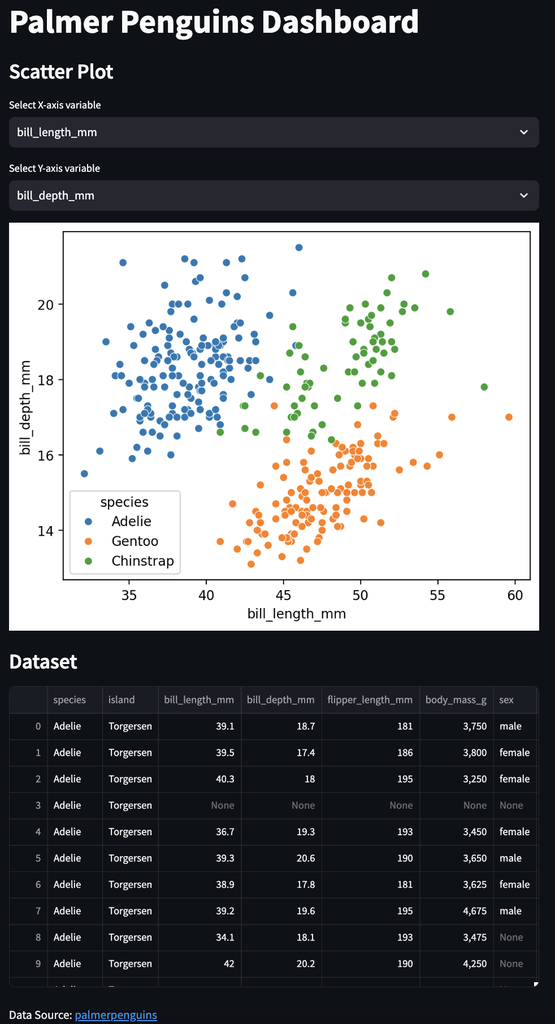

Streamlit Python App

## Dash

[figure not shown]

[Dash](https://dash.plotly.com/) is a framework developed by Plotly for building analytical web applications using Python. It’s especially well-suited for interactive visualizations and dashboards.

### Importing Libraries

In an `app.py` file, we’ll start by importing the following necessary libraries. `dash` and `dash.dependencies` [^3] are used for building web applications (similar to `shiny`), `pandas` is imported for data manipulation, `plotly.express` is used for creating plots (akin to `ggplot2`), and `dash_bootstrap_components` allows us to use Bootstrap themes for styling the app.

```python
import dash
from dash import dcc, html, dash_table
from dash.dependencies import Input, Output
import pandas as pd
import plotly.express as px
import dash_bootstrap_components as dbc
```

### Loading Data

Now that we’ve identified and imported the dependencies, we can read the data into the application using `pandas`. We can assign the URL to the raw `.csv` file to `url`, then have `pd.read_csv()` read the CSV file into a `pandas` DataFrame.[^4]

```python
url = "https://raw.githubusercontent.com/allisonhorst/palmerpenguins/main/inst/extdata/penguins.csv"
df = pd.read_csv(url)
```

### Utility Function

```python
def format_label(label):
    return label.replace('_', ' ').title()
```

This function replaces underscores with spaces and capitalizes words. In R, you would define a similar function using `gsub()` and `tools::toTitleCase()`.

### Define Columns

We want to omit the `year` column from the drop-dowwns, so we’ll define `numerical_columns` outside of the app so we don’t have to repeat this code later. Type `float64` or `int64` are numeric columns.

```python
numerical_columns = [col for col in df.select_dtypes(include=['float64', 'int64']).columns if col != 'year']
```

### Initialize App

`dash.Dash` creates a Dash app instance with Bootstrap styling by supplying `dbc.themes.BOOTSTRAP` to the `external_stylesheets` argument.[^5] This is somewhat similar to initializing a Shiny app with `shiny::shinyApp()`.

```python
app = dash.Dash(__name__, external_stylesheets=[dbc.themes.BOOTSTRAP])
```

In the case of initializing a Dash app, `__name__` is passed as an argument to the `dash.Dash()` constructor to specify the `name` of the application. We’ll encounter this again when we launch the application below.

### Layout

The majority of the code is contributed to defining the app layout using Bootstrap components.

- `dbc.Container`, `dbc.Row`, and `dbc.Col` arrange components in a grid, similar to layout functions in Shiny like `fluidPage()`, `sidebarLayout()`, etc.

  ```python
  app.layout = dbc.Container([
      dbc.Row([
          dbc.Col([

          ])
      ])
  ])
  ```

- `html.H1` creates a header, like `tags$h1()` in Shiny.

  ```python
    html.H1("Palmer Penguins Dashboard")
  ```

- `dcc.Dropdown` creates dropdown menus for user input, similar to `selectInput()` in Shiny.

  ```python
    dcc.Dropdown(
        id='x-axis',
        options=[{'label': col, 'value': col} for col in numerical_columns],
        value='bill_length_mm',
        clearable=False
    )
  ```

- `dcc.Graph` places a plot in the app, analogous to `plotOutput()` in Shiny.

  ```python
    dcc.Graph(id='scatter-plot')
  ```

- `dash_table.DataTable` displays data in a table, similar to `DT::dataTableOutput()` in R.

  ```python
    dash_table.DataTable(
        id='table',
        columns=[{"name": i, "id": i} for i in df.columns],
        data=df.to_dict('records'),
        page_size=10,
        style_table={'overflowX': 'auto'},
        style_cell={
            'height': 'auto',
            'minWidth': '140px', 'width': '140px', 'maxWidth': '140px',
            'whiteSpace': 'normal'
        }
    )
  ```

### Callback

The **callback function** updates the scatter plot based on dropdown inputs.

- The `@app.callback` decorator defines reactive behavior, similar to `observeEvent()` or `reactive()` in Shiny.[^6]

  ```python
    @app.callback(
        Output('scatter-plot', 'figure'),
        [Input('x-axis', 'value'),
         Input('y-axis', 'value')]
    )
  ```

- The function `update_scatter_plot` takes inputs from dropdowns and updates the plot, using `plotly.express` and our `format_label()` utility function to create the scatter plot, similar to using `ggplot2` in R.

  ```python
    def update_scatter_plot(x_axis, y_axis):
        fig = px.scatter(
            df, x=x_axis, y=y_axis, color='species',
            labels={x_axis: format_label(x_axis), y_axis: format_label(y_axis)},
            title=f'Scatter Plot of {format_label(x_axis)} vs {format_label(y_axis)}'
        )
        return fig
  ```

The full callback code is below:

**show/hide app callback in app.py**

```python
@app.callback(
    Output('scatter-plot', 'figure'),
    [Input('x-axis', 'value'),
     Input('y-axis', 'value')]
)
def update_scatter_plot(x_axis, y_axis):
    fig = px.scatter(
        df, x=x_axis, y=y_axis, color='species',
        labels={x_axis: format_label(x_axis), y_axis: format_label(y_axis)},
        title=f'Scatter Plot of {format_label(x_axis)} vs {format_label(y_axis)}'
    )
    return fig
```

### For loops

Python often relies on explicit iteration using for loops, which means Python code tends to use for loops more frequently than R code. The reason for this goes beyond the scope of this blog post, but it’s rooted in the distinct practices and strengths of each language.

Coming from R (and `purrr` or the `apply` family of functions), writing `for` loops can take some getting used to, so I’ve broken down the `numerical_columns` and `dcc.Dropdown()` examples from our Dash app.

```python
numerical_columns = [col for col in df.select_dtypes(include=['float64', 'int64']).columns if col != 'year']
```

1. `[col for col in ...]` is a list comprehension–it iterates over each column name (`col`) in the filtered list of column names.
2. `df` is a DataFrame, and `select_dtypes` is a method that filters the DataFrame columns based on their data types. It includes columns with data types `float64` and `int64` (similar to numeric types in R).
3. `.columns` retrieves the names of the columns that have been filtered by `select_dtypes`.
4. `if col != 'year'` is the condition to ensure that the column `year` is excluded from the resulting list, even if it has a numeric type.

```python
options=[{'label': col, 'value': col} for col in numerical_columns]
```

This `for` loop iterates over each column name (`col`) in the `numerical_columns` list.

1. For each column name, it creates a dictionary (`{'label': col, 'value': col}`).
2. `label` is the text displayed in the Dropdown, and `value` is the actual value assigned to this option.

```python
columns=[{"name": i, "id": i} for i in df.columns]
```

This `for` loop iterates over all columns of the DataFrame `df`.

1. For each column, it creates a dictionary with `name` and `id` both set to the column name.
2. These dictionaries are used to define the columns of the `dash_table.DataTable()`.

The entire app layout code is below:

**show/hide full Dash app in app.py**

```python
import dash
from dash import dcc, html, dash_table
from dash.dependencies import Input, Output
import pandas as pd
import plotly.express as px
import dash_bootstrap_components as dbc

# load the dataset
url = "https://raw.githubusercontent.com/allisonhorst/palmerpenguins/main/inst/extdata/penguins.csv"
df = pd.read_csv(url)

# remove the 'year' column
numerical_columns = [col for col in df.select_dtypes(include=['float64', 'int64']).columns if col != 'year']

# initialize the Dash app
app = dash.Dash(__name__, external_stylesheets=[dbc.themes.BOOTSTRAP])

# function to replace underscores with spaces
def format_label(label):
    return label.replace('_', ' ').title()

# app layout
app.layout = dbc.Container([
    dbc.Row(
        dbc.Col(
            html.H1("Palmer Penguins Dashboard"),
        width=12)
    ),
    dbc.Row(
        html.H3("Inputs")
    ),
    dbc.Row([
        dbc.Col(
            dcc.Dropdown(
                id='x-axis',
                options=[{'label': col, 'value': col} for col in numerical_columns],
                value='bill_length_mm',
                clearable=False
            ), width=3
        ),
        dbc.Col(
            dcc.Dropdown(
                id='y-axis',
                options=[{'label': col, 'value': col} for col in numerical_columns],
                value='bill_depth_mm',
                clearable=False
            ), width=3
        )
    ]),
    dbc.Row([
        dbc.Col([
            html.H3("Scatter Plot"),
            dcc.Graph(id='scatter-plot')
        ], width=6),
        dbc.Col([
            html.H3("Table"),
            dash_table.DataTable(
                id='table',
                columns=[{"name": i, "id": i} for i in df.columns],
                data=df.to_dict('records'),
                page_size=10,
                style_table={'overflowX': 'auto'},
                style_cell={
                    'height': 'auto',
                    'minWidth': '140px', 'width': '140px', 'maxWidth': '140px',
                    'whiteSpace': 'normal'
                }
            )
        ], width=6)
    ])
])

# callback to update the scatter plot
@app.callback(
    Output('scatter-plot', 'figure'),
    [Input('x-axis', 'value'),
     Input('y-axis', 'value')]
)
def update_scatter_plot(x_axis, y_axis):
    fig = px.scatter(
        df, x=x_axis, y=y_axis, color='species',
        labels={x_axis: format_label(x_axis), y_axis: format_label(y_axis)},
        title=f'Scatter Plot of {format_label(x_axis)} vs {format_label(y_axis)}'
    )
    return fig

# run the app
if __name__ == '__main__':
    app.run_server(debug=True)
```

### Run the App

The code below runs the application. Note that the `__name__ == '__main__'` condition corresponds to the `dash.Dash(__name__, ...)` we used to initialize the application above.

```python
if __name__ == '__main__':
    app.run_server(debug=True)
```

Run the application by running the following commands in the terminal:

```bash
python app.py
```

```bash
Dash is running on http://127.0.0.1:8050/

 * Serving Flask app 'app'
 * Debug mode: on
```

Use `Cmd`/`Ctrl` + click on the URL to open the web browser with our application:

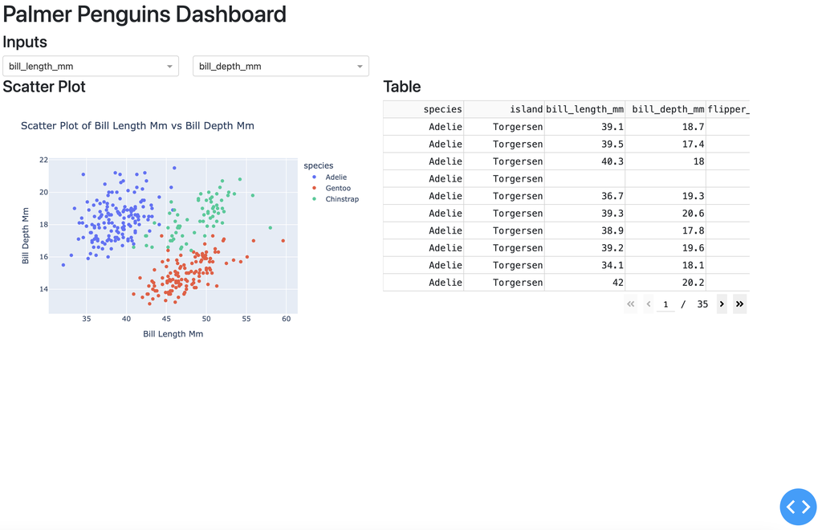

Penguins Dash App

The Dash application has an interactive scatter plot (with hover features) with a side-by-side table display. The layout functions in Dash give us more control over output placement in the UI, and the additional HTML functions give us the ability to build our application up like a standard webpage (or Shiny app).

## Recap

In summary, [Bokeh](https://docs.bokeh.org/en/latest/) is excellent for creating detailed and interactive visualizations, comparable to `ggplot2` and `plotly` for interactive plots, but it’s not focused on developing complete applications. [Streamlit](https://docs.streamlit.io/) is very user-friendly and ideal for quickly building and sharing simpler web apps, but with fewer options for customization. [Dash](https://dash.plotly.com/) is capable of developing highly customizable and complex web applications (similar to Shiny), but has a steeper learning curve than Streamlit.

You can view the code used to create the apps in this [repo.](https://github.com/mjfrigaard/py-apps/tree/main)

## Footnotes

[^1]: `venv` is a module that comes built-in with [Python 3.3 and later versions](https://docs.python.org/3/library/venv.html), so we do not need to install it separately.
[^2]: [`st.write()`](https://docs.streamlit.io/develop/api-reference/write-magic/st.write) is incredibly versatile. We’re passing it Markdown-formatted text in this example, but it can be used to display DataFrames, models, and more.
[^3]: Watch [The Dash Callback - Input, Output, State, and more](https://youtu.be/mTsZL-VmRVE?si=C6mkTzQYAI0FlCRJ) on the [Charming Data YouTube channel](https://www.youtube.com/@CharmingData).
[^4]: `pd.read_csv` is analogous to `read.csv` or `readr::read_csv` in R.
[^5]: Read all the arguments for dash.Dash in the [documentation.](https://dash.plotly.com/reference#dash.dash)
[^6]: Read more about Dash callback definitions in the [documentation](https://dash.plotly.com/basic-callbacks).

[interactive chart not shown]